# Reproducible Research Project 1

David Boberski

5/30/2020

#### Q1. Code for reading in the dataset and/or processing the data

**Loading and preprocessing the data**

1. Load the data (i.e. read.csv()
2. Process/transform the data (if necessary) into a format suitable for your analysis

```r
#1 Code for reading in the dataset and processing the data

setwd("/Users/davidboberski/Desktop/Dad/R files/Course 5/")
data <- read.csv("activity.csv", sep = ',', header = TRUE, stringsAsFactors=FALSE)
data <- as.data.frame(data)
data <- na.omit(data)
head(data)
```

```
##     steps       date interval
## 289     0 2012-10-02        0
## 290     0 2012-10-02        5
## 291     0 2012-10-02       10
## 292     0 2012-10-02       15
## 293     0 2012-10-02       20
## 294     0 2012-10-02       25
```

#### Q2. Histogram of the total number of steps taken each day

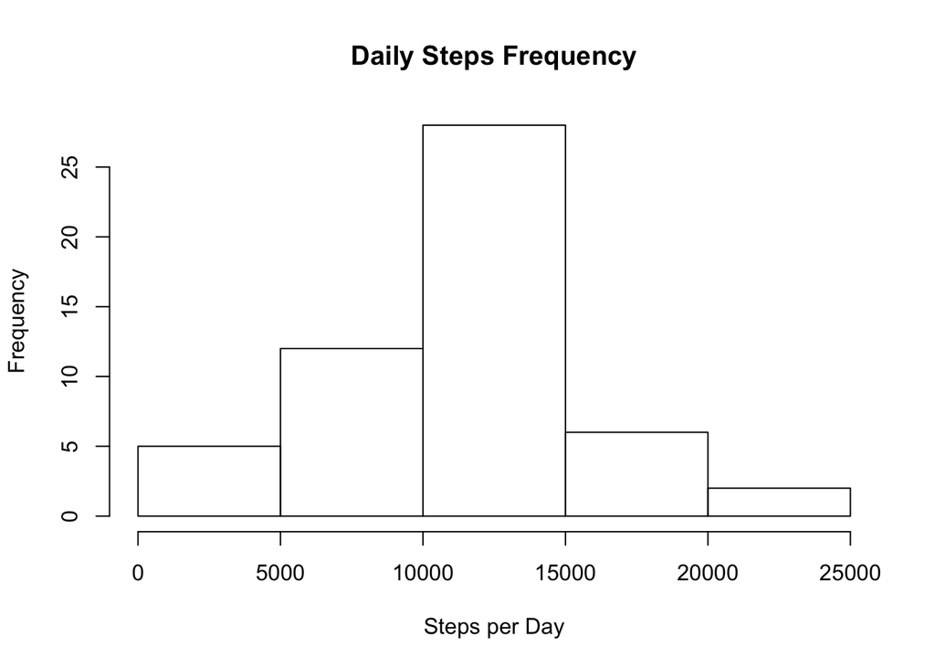

```r
library(plyr)
data <- ddply(data,.(date),numcolwise(sum))
#png("Plot1.png", width=480, height=480)
hist(data$steps,
     main="Daily Steps Frequency",
     xlab="Steps per Day"
     )
```

**What is mean total number of steps taken per day?**

*For this part of the assignment, you can ignore the missing values in the dataset.*

```r
data <- read.csv("activity.csv", sep = ',', header = TRUE, stringsAsFactors=FALSE)
data <- as.data.frame(data)
data <- na.omit(data)
#head(data)

#head(data.mean)
#head(data.median)

mean(data$steps)
```

```
## [1] 37.3826
```

```r
median(data$steps)
```

```
## [1] 0
```

#### Q4. Time series plot of the average number of steps taken

```r
library(plyr)
library(tidyverse)
library(reshape2)
data <- read.csv("activity.csv", sep = ',', header = TRUE, stringsAsFactors=FALSE)
data <- as.data.frame(data)
data <- na.omit(data)
head(data)
```

```
##     steps       date interval
## 289     0 2012-10-02        0
## 290     0 2012-10-02        5
## 291     0 2012-10-02       10
## 292     0 2012-10-02       15
## 293     0 2012-10-02       20
## 294     0 2012-10-02       25
```

```r
data.mean <- ddply(data,.(date),numcolwise(mean))
data.median <- ddply(data,.(date),numcolwise(median))

plot.data <- cbind(data.mean$date, data.mean$steps,data.median$steps)
colnames(plot.data) <- c("Date","Mean Steps", "Median Steps")
plot.data <- as.data.frame(plot.data)
head(plot.data)
```

```
##         Date       Mean Steps Median Steps
## 1 2012-10-02           0.4375            0
## 2 2012-10-03 39.4166666666667            0
## 3 2012-10-04 42.0694444444444            0
## 4 2012-10-05 46.1597222222222            0
## 5 2012-10-06 53.5416666666667            0
## 6 2012-10-07 38.2465277777778            0
```

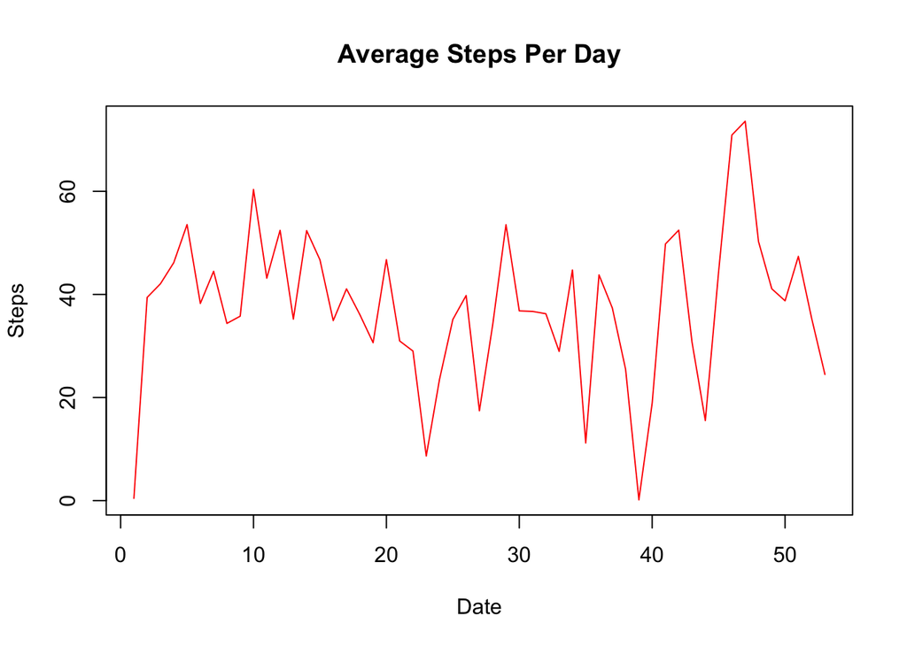

```r
meltdf <- melt(plot.data,id="Date")
plot(data.mean$steps,type="l",col="red",
     main = "Average Steps Per Day" ,
     ylab = "Steps",
     xlab = "Date")
```

**What is the average daily activity pattern?**

```r
library(plyr)
library(tidyverse)
library(reshape2)

data <- read.csv("activity.csv", sep = ',', header = TRUE, stringsAsFactors=FALSE)
data <- as.data.frame(data)
data <- na.omit(data)
head(data)
```

```
##     steps       date interval
## 289     0 2012-10-02        0
## 290     0 2012-10-02        5
## 291     0 2012-10-02       10
## 292     0 2012-10-02       15
## 293     0 2012-10-02       20
## 294     0 2012-10-02       25
```

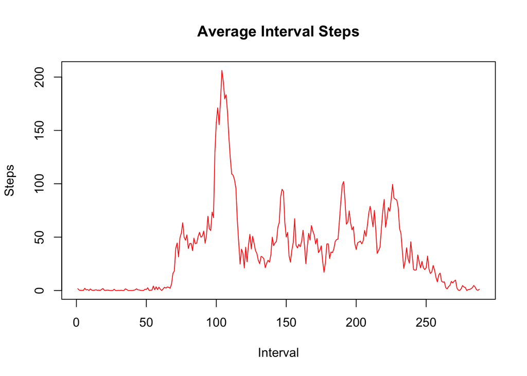

```r
data <- ddply(data,.(interval),numcolwise(mean))

plot(data$steps,type="l",col="red",
     main = "Average Interval Steps" ,
     ylab = "Steps",
     xlab = "Interval")
```

```r
colMax <- function(data) sapply(data, max, na.rm = TRUE)
colMax(data)
```

```
##  interval     steps
## 2355.0000  206.1698
```

#### Q6. Code to describe and show a strategy for imputing missing data

**Imputing missing values**

*To impute missing data we simply use the previous available value using “na.locf” function.*

Note that there are a number of days/intervals where there are missing values (coded as NA). The presence of missing days may introduce bias into some calculations or summaries of the data.

1. Calculate and report the total number of missing values in the dataset (i.e. the total number of rows with NAs)  
   2.. Devise a strategy for filling in all of the missing values in the dataset. The strategy does not need to be sophisticated. For example, you could use the mean/median for that day, or the mean for that 5-minute interval, etc.
2. Create a new dataset that is equal to the original dataset but with the missing data filled in.
3. Make a histogram of the total number of steps taken each day and Calculate and report the mean and median total number of steps taken per day. Do these values differ from the estimates from the first part of the assignment? What is the impact of imputing missing data on the estimates of the total daily number of steps?

```r
library(zoo)
library(tidyverse)
library(reshape2)

data <- read.csv("activity.csv", sep = ',', header = TRUE, stringsAsFactors=FALSE)
data <- as.data.frame(data)

# do not remove missing NAs and calculate mean / median before imputing values
#data <- na.omit(data)
mean(data$steps)
```

```
## [1] NA
```

```r
median(data$steps)
```

```
## [1] NA
```

```r
# count the number of NAs in each column
sum(is.na(data$steps))
```

```
## [1] 2304
```

```r
sum(is.na(data$sdate))
```

```
## [1] 0
```

```r
sum(is.na(data$interval))
```

```
## [1] 0
```

```r
# impute missing values by using the previous good value
data <- na.locf(data)
head(data)
```

```
##     steps       date interval
## 289     0 2012-10-02        0
## 290     0 2012-10-02        5
## 291     0 2012-10-02       10
## 292     0 2012-10-02       15
## 293     0 2012-10-02       20
## 294     0 2012-10-02       25
```

```r
mean(data$steps)
```

```
## [1] 33.0213
```

```r
median(data$steps)
```

```
## [1] 0
```

[figure not shown]

```r
library(plyr)
library(tidyverse)
library(reshape2)

data <- read.csv("activity.csv", sep = ',', header = TRUE, stringsAsFactors=FALSE)
data <- as.data.frame(data)
# data <- na.omit(data)

data <- na.locf(data)

hist(data$steps,
     main="Daily Steps Frequency, With Imputed Missing Values",
     xlab="Steps per Day")
```

** From the table below we can see that steps pick up over the weekend.**

```r
library(plyr)
library(tidyverse)
library(reshape2)

data <- read.csv("activity.csv", sep = ',', header = TRUE, stringsAsFactors=FALSE)
data <- as.data.frame(data)
# data <- na.omit(data)

# fill in NAs with last available value
data <- na.locf(data)

#add new column with weekdays
data$day <- weekdays(as.Date(data$date))

data <- read.csv("activity.csv", sep = ',', header = TRUE, stringsAsFactors=FALSE)
data <- as.data.frame(data)
data <- na.locf(data)
head(data)
```

```
##     steps       date interval
## 289     0 2012-10-02        0
## 290     0 2012-10-02        5
## 291     0 2012-10-02       10
## 292     0 2012-10-02       15
## 293     0 2012-10-02       20
## 294     0 2012-10-02       25
```

```r
# create new column with day of the week
data$day <- weekdays(as.Date(data$date))

data.by.day <- ddply(data,.(day),numcolwise(mean))
data.by.day
```

```
##         day    steps interval
## 1    Friday 33.37886   1177.5
## 2    Monday 30.30556   1177.5
## 3  Saturday 38.08507   1177.5
## 4    Sunday 37.30208   1177.5
## 5  Thursday 25.34799   1177.5
## 6   Tuesday 31.07485   1177.5
## 7 Wednesday 36.39120   1177.5
```

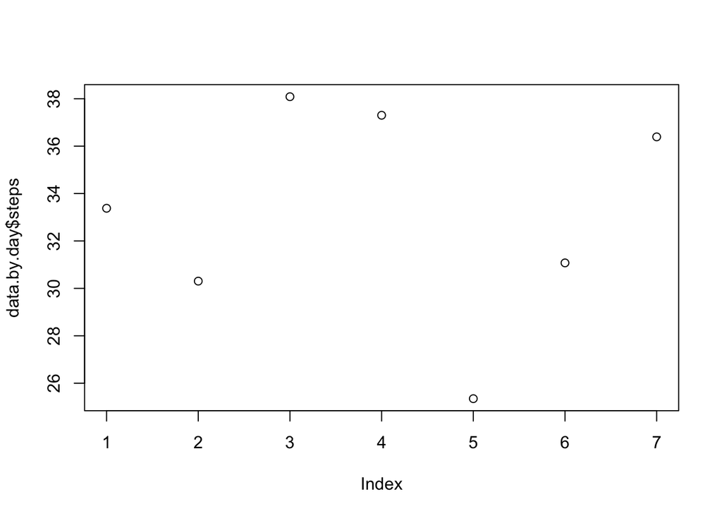

```r
plot(data.by.day$steps)
```

#### Q9. All of the R code needed to reproduce the results (numbers, plots, etc.) in the report

The relevant code is listed in each question.